# Multilevel models

multilevel models

Parameter estimation in clustered data

true  
05-28-2021

I am using the native `pipe` operator, which is new to R 4.10. This pipe operator is written as a `|` followed by a `>`. In this document, the operator is printed as `|>`, due to the fact that I am using font ligatures. If the pipe doesn’t work for you, simply replace it with the older pipe `%>%`.

```r
library(tidyverse)
library(brms)
library(tidybayes)

theme_set(theme_grey(base_size = 14) +
            theme(panel.grid = element_blank()))
```

We now explore the difference between fitting a model with population-level effects and a mdoel with varying effects to the same data.

We’ll generate some normally distributed data consisting of three conditions, with means of 0, 1 and 2. Each group has standard deviation of 0.5. We’ll draw 20 observations per condition.

Note that we haven’t anything about the structure in the data, so these could be three independent samples, or the could be data from three subjects in one condition (even though I have called the grouping variable `condition`).

```r
set.seed(5)

n_obs <- 20
n_conditions <-  3
condition_means <- c(0, 1, 2)
sigma <- 0.5

d <- tibble(condition = rep(LETTERS[1:n_conditions], n_obs),
            response = rnorm(n_obs * n_conditions, condition_means, sigma)) |>
  arrange(condition)
```

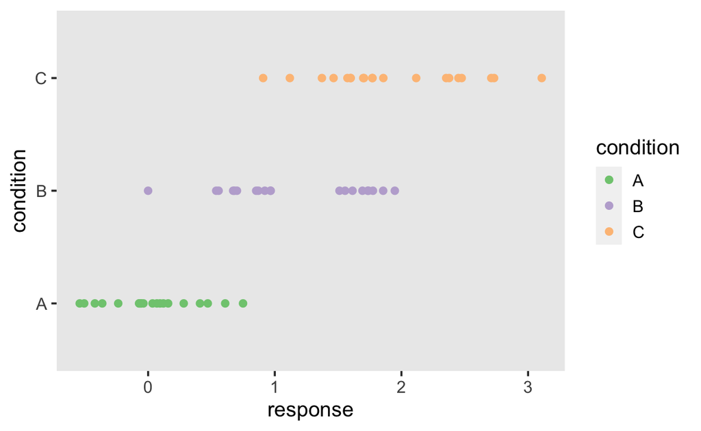

```r
p1 <- d |>
  ggplot(aes(response, condition, color = condition)) +
  geom_point( size = 2) +
  scale_color_brewer(type = "qual")

p1
```

We can compute the condition mean and SD, and then add these to the plot.

```r
condition_means <- d |>
  group_by(condition) |>
  summarise(mean = mean(response),
            sd = sd(response))
```

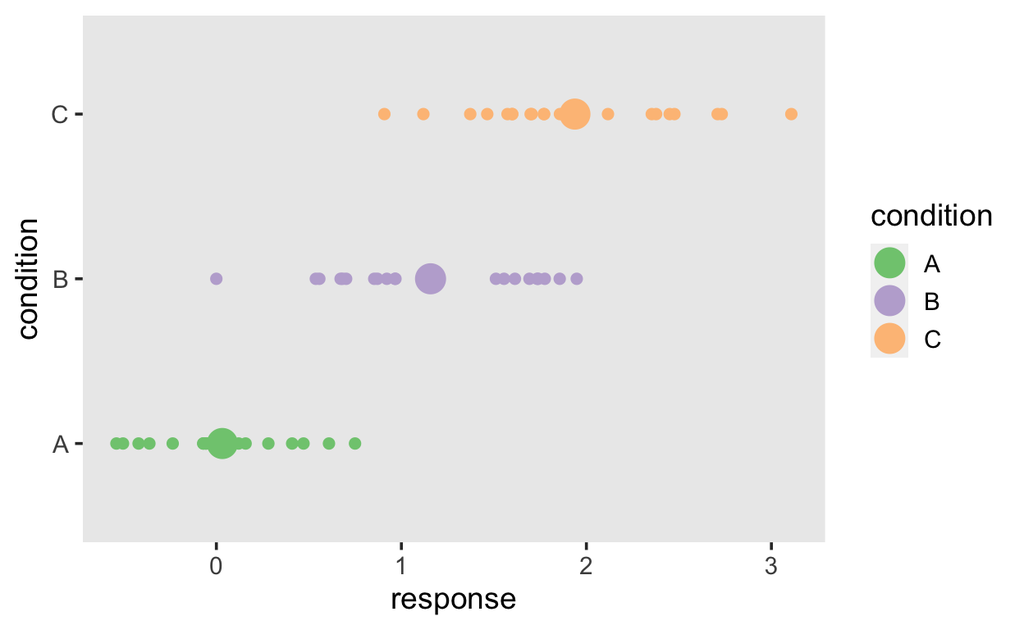

```r
p1 +
  geom_point(aes(mean, condition, color = condition),
             data = condition_means,
             size = 6)
```

## Population-level effects

Let’s first assume that the data are from independent samples. We want to estimate the three condition means, with the goal of comparing these. Since none of the these conditions is an obvious reference category, let’s just estimate all three means.

```r
formula1 <- response ~ 0 + condition
```

The statistical formula can be written as:

$$\operatorname{response} = \beta_{\operatorname{A}}(\operatorname{condition}_{\operatorname{A}}) + \beta_{\operatorname{B}}(\operatorname{condition}_{\operatorname{B}}) + \beta_{\operatorname{C}}(\operatorname{condition}_{\operatorname{C}}) + \epsilon$$

This states that the expected value of the response variable is either $\beta_{\operatorname{A}}$, $\beta_{\operatorname{B}}$ or $\beta_{\operatorname{C}}$, since these are indicator variables.

We can inspect the default priors.

```r
get_prior(formula1, data = d) |>
  as_tibble() |> select(1:4)
```

```
# A tibble: 5 x 4
  prior                  class coef         group
  <chr>                  <chr> <chr>        <chr>
1 ""                     b     ""           ""
2 ""                     b     "conditionA" ""
3 ""                     b     "conditionB" ""
4 ""                     b     "conditionC" ""
5 "student_t(3, 0, 2.5)" sigma ""           ""
```

The priors on the regression coefficients are flat. This should be avoided, so we’ll use normal distributions centred at 1, which is just the overall mean.

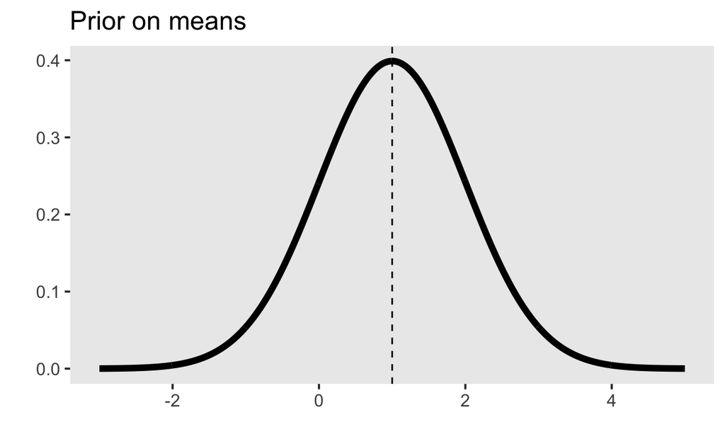

```r
priors1 <- prior(normal(1, 1), class = b)

tibble(x = seq(-3, 5, by = 0.01),
       y = dnorm(x, 1, 1)) |>
  ggplot(aes(x, y)) + geom_line(size = 2) +
  geom_vline(xintercept = 1, linetype = 2) +
  ylab("") + xlab("") +
  ggtitle("Prior on means")
```

I usually save the model file in order to avoid having to recompile and sample unless the model specification has changed.

```r
m1 <- brm(formula1,
          prior = priors1,
          data = d,
          file = "../../models/02-m1")
```

Looking at the posterior estimates, we note that the means are similar to the sample means.

```r
summary(m1)
```

[output not shown]

For reference, here are the sample means:

```r
condition_means
```

```
# A tibble: 3 x 3
  condition   mean    sd
  <chr>      <dbl> <dbl>
1 A         0.0321 0.353
2 B         1.16   0.562
3 C         1.94   0.578
```

However, stan gives us full posterior distributions, not just point estimates. We can visualize these using the `type` argument in `mcmc_plots()`.

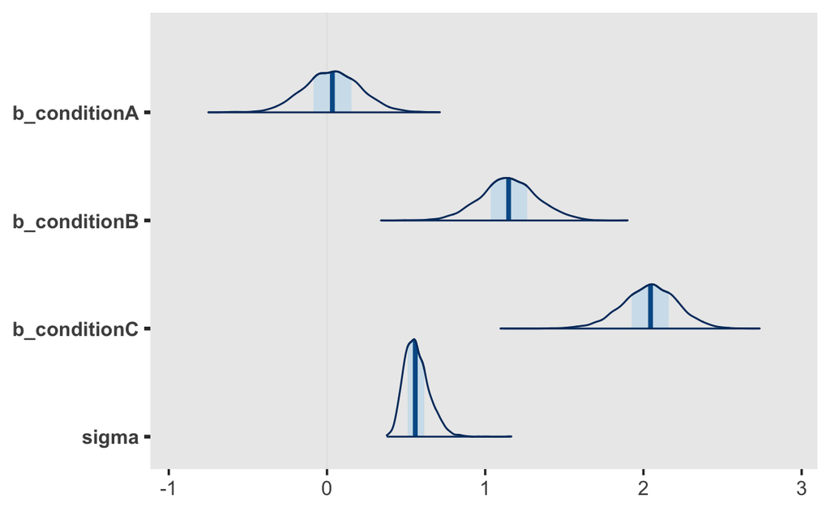

```r
mcmc_plot(m1, type = "areas")
```

We can extract the population-level effects using `fixef()`, which is named like this to be consistent with other modelling packages in R. We can get either summaries, or the samples.

```r
fixef(m1)
```

```
             Estimate Est.Error       Q2.5     Q97.5
conditionA 0.03302576 0.1814484 -0.3152898 0.3900089
conditionB 1.15011637 0.1805871  0.7891059 1.5103085
conditionC 2.03947646 0.1756655  1.6853433 2.3745034
```

```r
m1_pop <- fixef(m1, summary = FALSE)
```

The samples can be summarized, resulting in the same numbers as above.

```r
m1_pop |>
  as_tibble() |>
  pivot_longer(everything(),
               names_to = "condition",
               values_to = "mean") |>
  group_by(condition) |>
  summarise(estimate = mean(mean),
            sd = sd(mean),
            q2.5 = quantile(mean, 0.025),
            q97.5 = quantile(mean, 0.975))
```

```
# A tibble: 3 x 5
  condition  estimate    sd   q2.5 q97.5
  <chr>         <dbl> <dbl>  <dbl> <dbl>
1 conditionA   0.0330 0.181 -0.315 0.390
2 conditionB   1.15   0.181  0.789 1.51
3 conditionC   2.04   0.176  1.69  2.37
```

## Hierarchical model

Now let’s treat the data as if they were clustered, e.g. repeated measures of a three subject in a single condition. If it helps, we can rename the condition variable to `subject`:

```r
d <- d |> select(subject = condition, response)
```

```r
subject_means <- d |>
  group_by(subject) |>
  summarise(mean = mean(response),
            sd = sd(response))
```

We now want to estimate the population-level mean, averaged over subjects, but we are also interested in the subject-level means. This is a partial pooling model, as opposed to the no-pooling model from above.

In `brms`, these are called group-level effects, as they are varying effects for each level of a grouping variable.

The formula states that we are predicting `repsonse` as an average effect, with varying effects for each subject.

```r
formula2 <- response ~ 1 + (1 | subject)
```

$$\begin{aligned}
\operatorname{response}_{i} &\sim N \left(\alpha_{j[i]}, \sigma^2 \right) \\
\alpha_{j} &\sim N \left(\mu_{\alpha_{j}}, \sigma^2_{\alpha_{j}} \right)
\text{, for subject j = 1,} \dots \text{,J}
\end{aligned}$$
One way to think of this is that the subject means $\alpha_{j}$ are themselves drawn from a normal distribution, with mean $\mu_{\alpha}$ and SD $\sigma_{\alpha}$. THis is what makes this a hierarchical problem—subject parameters are random draws from a super-population., and are therefore related, in the sense that they have a commmon distribution. In mathematical terms, the subject parameters are $i.i.d$ and are exchangeable.

This means that we could change the ordering or the labelling of the subjects, and this would not affect the outcome.

Let’s see what priors we get for this model.

```r
get_prior(formula2, data = d) |>
  as_tibble() |> select(1:4)
```

```
# A tibble: 5 x 4
  prior                    class     coef        group
  <chr>                    <chr>     <chr>       <chr>
1 "student_t(3, 0.9, 2.5)" Intercept ""          ""
2 "student_t(3, 0, 2.5)"   sd        ""          ""
3 ""                       sd        ""          "subject"
4 ""                       sd        "Intercept" "subject"
5 "student_t(3, 0, 2.5)"   sigma     ""          ""
```

We now have a `student_t(3, 0.9, 2.5)` prior on the intercept, which is the overall mean, and we have a `student_t(3, 0, 2.5)` prior on the SD of the subjects’ varying effects around the mean. This is the term $\sigma_{\alpha}$. Because SD parameters must be $>0$, $\sigma_{\alpha}$ has a half student-t distribution. The parameter `sigma` is the residual standard deviation.

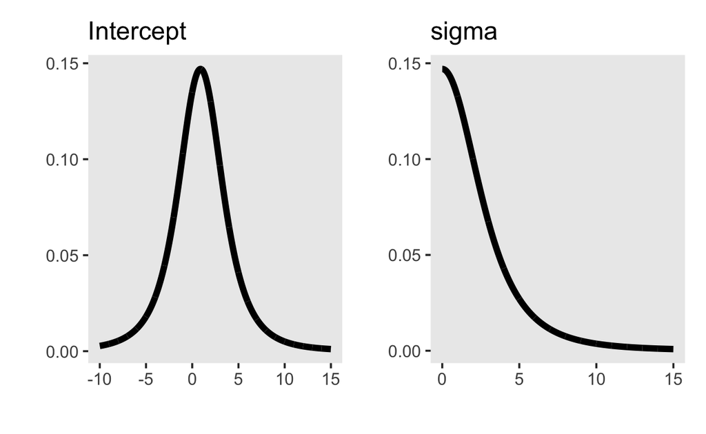

```r
library(patchwork)

p_intercept <- tibble(x = seq(-10, 15, by = 0.01),
       Intercept = dstudent_t(x, 3, 0.9, 2.5)) |>
  # pivot_longer(c(Intercept, sd), names_to = "prior", values_to = "y") |>
  ggplot(aes(x, Intercept)) + geom_line(size = 2) +
  ylab("") + xlab("") +
  ggtitle("Intercept")

p_sd <- tibble(x = seq(0, 15, by = 0.01),
       sd = dstudent_t(x, 3, 0, 2.5)) |>
  ggplot(aes(x, sd)) + geom_line(size = 2) +
  ylab("") + xlab("") +
  ggtitle("sigma")

p_intercept + p_sd
```

Using the default priors is not a good idea at all here; the priors are too wide. This means that the sampling algorithm will be trying to explore parts of the parameter space where the likelihood is very small. This is very inefficient, and Stan gives us a warning if we try to run this model.

```r
m2 <- brm(formula2,
          data = d,
          control = list(adapt_delta = 0.9),
          file = "../../models/02-m2")
```

```r
summary(m2)
```

[output not shown]

The esatimate for the intercept and the SD is very uncertain.

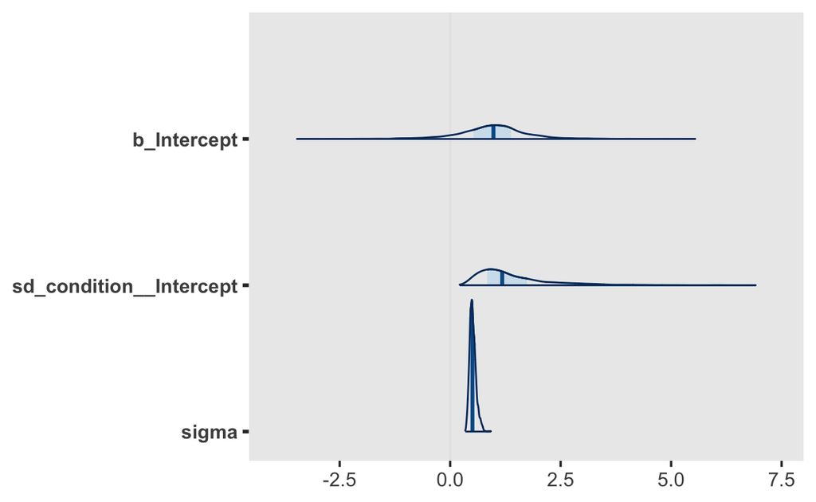

```r
mcmc_plot(m2, type = "areas")
```

We can do better that that, by choosing more informative priors:

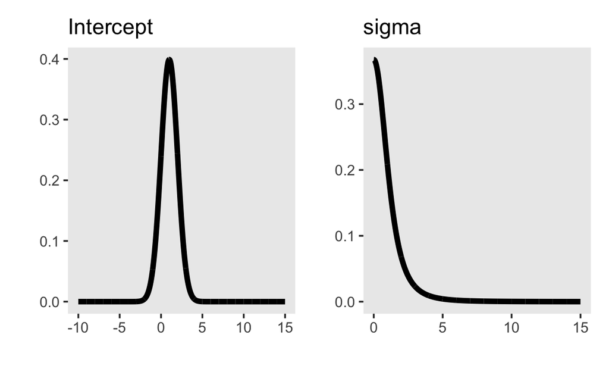

```r
p_intercept <- tibble(x = seq(-10, 15, by = 0.01),
       Intercept = dnorm(x, 1, 1)) |>
  ggplot(aes(x, Intercept)) + geom_line(size = 2) +
  ylab("") + xlab("") +
  ggtitle("Intercept")

p_sd <- tibble(x = seq(0, 15, by = 0.01),
       sd = dstudent_t(x, 3, 0, 1)) |>
  ggplot(aes(x, sd)) + geom_line(size = 2) +
  ylab("") + xlab("") +
  ggtitle("sigma")

p_intercept + p_sd
```

```r
priors3 <- prior(normal(1, 1), class = Intercept) +
  prior(student_t(3, 0, 1), class = sd)

m3 <- brm(formula2,
          data = d,
          prior = priors3,
          control = list(adapt_delta = 0.9),
          file = "../../models/02-m3")
```

```r
summary(m3)
```

```
 Family: gaussian
  Links: mu = identity; sigma = identity
Formula: response ~ 1 + (1 | subject)
   Data: d (Number of observations: 60)
Samples: 4 chains, each with iter = 2000; warmup = 1000; thin = 1;
         total post-warmup samples = 4000

Group-Level Effects:
~subject (Number of levels: 3)
              Estimate Est.Error l-95% CI u-95% CI Rhat Bulk_ESS
sd(Intercept)     1.10      0.52     0.46     2.44 1.00     1168
              Tail_ESS
sd(Intercept)     1469

Population-Level Effects:
          Estimate Est.Error l-95% CI u-95% CI Rhat Bulk_ESS Tail_ESS
Intercept     1.02      0.52    -0.07     2.08 1.00     1225     1246

Family Specific Parameters:
      Estimate Est.Error l-95% CI u-95% CI Rhat Bulk_ESS Tail_ESS
sigma     0.52      0.05     0.43     0.63 1.00     1991     2231

Samples were drawn using sampling(NUTS). For each parameter, Bulk_ESS
and Tail_ESS are effective sample size measures, and Rhat is the potential
scale reduction factor on split chains (at convergence, Rhat = 1).
```

It isn’t that obvious, but the estimate of the intercept is narrower in model 3.

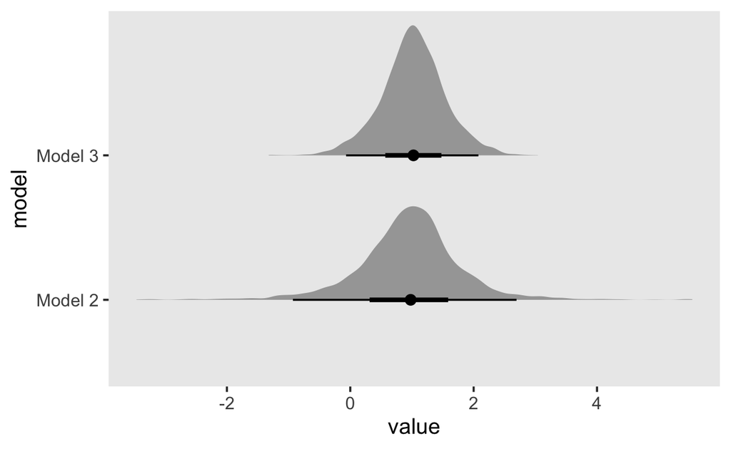

```r
posts <- tibble(name  = str_c("m", 2:3),
                model = str_c("Model ", 2:3)) |>
  mutate(fit = map(name, get)) |>
  mutate(post = map(fit, posterior_samples))

# head(posts)

posts <- posts |>
  select(-fit) |>
  unnest(post)

posts_mean <- posts |>
  pivot_longer(starts_with("b_Intercept"), names_to = "subject",
               values_to = "value")
posts_mean |>
  ggplot(aes(x = value, y = model)) +
  stat_halfeye()
```

The same is true of the standard deviation of the varying intercepts— in model 3, we have a mean of $1.10$ with a 95% of $[0.46, 2.44]$, where in model 2 we have a mean of $1.42$ and a 95% of $[0.47, 3.64]$.

### Varying effects

We are not just interested in the population-level effect; we want the subject effects too.

While you can get these using the `ranef()` function (`ranef(m3)` gives you a summary, you have to set `summary = FALSE` to get the samples (`ranef(m3, summary = FALSE)`).

I really like using `tidybayes` for this, as it’s functions return *tidy* data frames.

If we want just the varying effects, we can use `r_subject[subject]` with the placeholer `subject`. This will be replaced by the subject ID

```r
m3 |>
  spread_draws(r_subject[subject])
```

```
# A tibble: 12,000 x 5
# Groups:   subject [3]
   subject r_subject .chain .iteration .draw
   <chr>       <dbl>  <int>      <int> <int>
 1 A          -1.05       1          1     1
 2 A          -2.29       1          2     2
 3 A          -0.751      1          3     3
 4 A          -1.98       1          4     4
 5 A          -1.70       1          5     5
 6 A          -1.21       1          6     6
 7 A          -1.05       1          7     7
 8 A          -1.15       1          8     8
 9 A          -0.565      1          9     9
10 A          -0.888      1         10    10
# … with 11,990 more rows
```

The varying effects are centred at zero. If you want the subjects-specific means, you have to add the population-level estimate.

```r
m3 %>%
  spread_draws(b_Intercept, r_subject[subject]) |>
  median_qi(subject_mean = b_Intercept + r_subject)
```

```
# A tibble: 3 x 7
  subject subject_mean .lower .upper .width .point .interval
  <chr>          <dbl>  <dbl>  <dbl>  <dbl> <chr>  <chr>
1 A             0.0482 -0.177  0.276   0.95 median qi
2 B             1.15    0.932  1.38    0.95 median qi
3 C             1.92    1.69   2.14    0.95 median qi
```

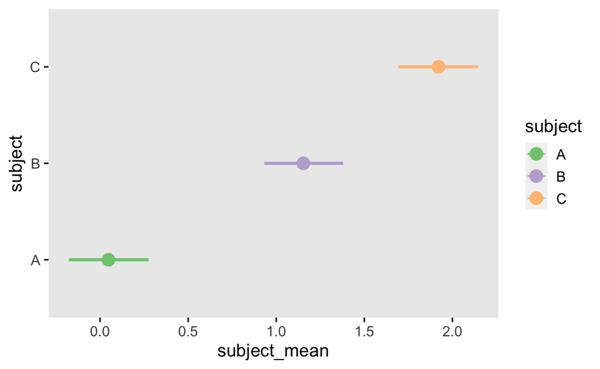

```r
p3_shrinkage <- m3 |>
  spread_draws(b_Intercept, r_subject[subject]) |>
  median_qi(subject_mean = b_Intercept + r_subject) |>
  ggplot(aes(y = subject, x = subject_mean,
             color = subject)) +
  geom_pointinterval(aes(xmin = .lower, xmax = .upper), point_size = 4) +
  scale_color_brewer(type = "qual")
p3_shrinkage
```

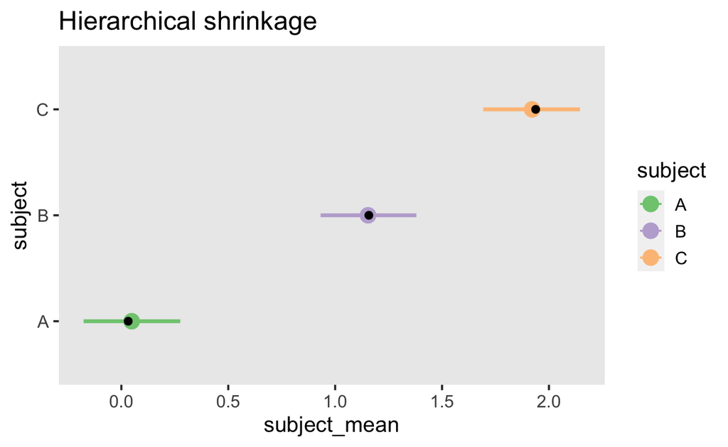

```r
p3_shrinkage +
    geom_point(aes(mean, subject),
             data = subject_means,
             size = 2, color = "black") +
  ggtitle("Hierarchical shrinkage")
```

Plotting the no-pooling estimates alongside the pooled estimates reveals that the partial-pooling estimates are less extreme that the no-pooling ones. This is due to the fact that the estimates are drawn to the overall mean, and is known as **shrinkage**.

## Multilevel example

Now we will simulate data from a pre-post treatment study. The treatment is applied to every subject, so is what is commonly referred to as a within-subject variable.

This function generates data for `n_subjects` subjects in two conditions, with the following parameters:

```r
params <- tribble(~Parameter, ~`Default value`, ~Desccription,
                  "a", 3.5, "average pre-treatment effect (intercepts)",
                  "b", -1, "average difference between pre and post",
                  "sigma_a", 1, "std dev in intercepts",
                  "sigma_b", 0.8, "std dev in differences (slopes)",
                  "rho", -0.7, "correlation between intercepts and slopes",
                  "n_subject", 10, "no. subjects",
                  "n_trials", 20, "no. trials per subject per condition",
                  "sigma", 0.5, "residual standard deviation")
params |>
    kableExtra::kbl() |>
    kableExtra::kable_paper("hover", full_width = T)
```

| Parameter | Default value | Desccription |
| --- | --- | --- |
| a | 3.5 | average pre-treatment effect (intercepts) |
| b | -1.0 | average difference between pre and post |
| sigma_a | 1.0 | std dev in intercepts |
| sigma_b | 0.8 | std dev in differences (slopes) |
| rho | -0.7 | correlation between intercepts and slopes |
| n_subject | 10.0 | no. subjects |
| n_trials | 20.0 | no. trials per subject per condition |
| sigma | 0.5 | residual standard deviation |

```r
simulate_treatment <- function(a = 3.5,
                              b = -1,
                              sigma_a = 1,
                              sigma_b = 0.8,
                              rho = -0.7,
                              n_subjects = 10,
                              n_trials = 20,
                              sigma = 0.5) {

    # Ccombine the terms
    mu <- c(a, b)
    cov_ab <- sigma_a * sigma_b * rho
    SD  <- matrix(c(sigma_a^2, cov_ab,
                       cov_ab, sigma_b^2), ncol = 2)

   #  sigmas <- c(sigma_a, sigma_b)          # standard deviations
   #  rho <- matrix(c(1, rho,             # correlation matrix
   #                 rho, 1), nrow = 2)
   #
   # # now matrix multiply to get covariance matrix
   # SD <- diag(sigmas) %*% rho %*% diag(sigmas)

    varying_effects <-
        MASS::mvrnorm(n_subjects, mu, SD) |>
        # as_tibble(.name_repair = "unique") |>
        data.frame() |>
        purrr::set_names("a_j", "b_j")

    d_linpred <-
        varying_effects |>
        mutate(subject  = 1:n_subjects) |>
        expand(nesting(subject, a_j, b_j), post = c(0, 1)) |>
        mutate(mu = a_j + b_j * post,
               sigma = sigma) |>
        mutate(treatment = ifelse(post == 0, "pre", "post"),
               treatment = factor(treatment, levels = c("pre", "post")))

    d <- d_linpred |>
        slice(rep(1:n(), each = n_trials)) |>
        mutate(response = rnorm(n = n(), mean = mu, sd = sigma))

   d
}
```

```r
plot_linpred <- function(d, violin = FALSE) {

  d_linpred <- d |>
  group_by(subject, treatment) |> distinct(mu, .keep_all = TRUE)

  p <- d_linpred |>
    ggplot(aes(x = treatment, y = mu))

  if (isTRUE(violin)) {
  p <- p +
      geom_violin(aes(x = treatment, y = response,
                          fill = treatment),
                  alpha = 0.5,
                  data = d) +
      geom_jitter(aes(x = treatment, y = response,
                          color = treatment),
                  width = 0.1, size = 2,
                  data = d)
  }

  p <- p +
    geom_line(aes(group = 1), color = "#8B9DAF", size = 1, linetype = 3) +
    geom_point(aes(fill = treatment),
               shape = 21,
               colour = "black",
               size = 4,
               stroke = 2) +
    scale_fill_brewer(type = "qual") +
    scale_color_brewer(type = "qual") +
    coord_cartesian(ylim = c(0, 8)) +
    ylab("Response") +
    theme(legend.position = "none",
          axis.ticks.x    = element_blank()) +
    facet_wrap(~ subject) +
  ggtitle("Linear predictor")

  p
}
```

```r
set.seed(52)
d1 <- simulate_treatment(n_subjects = 5)
```

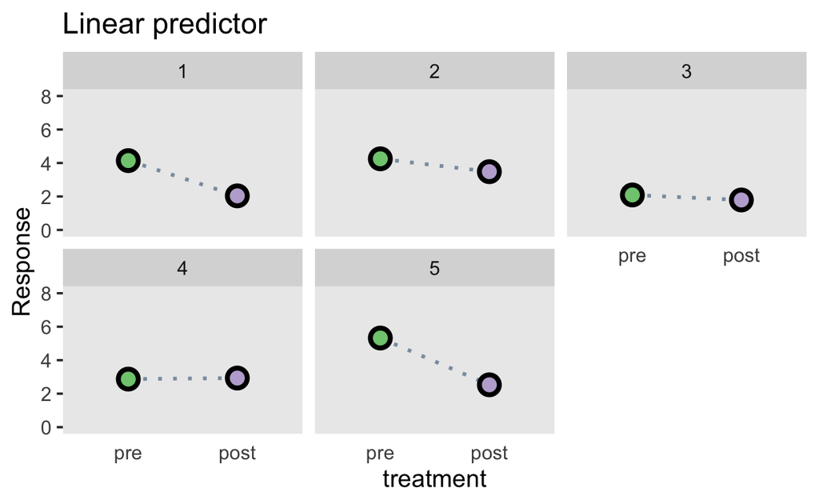

```r
plot_linpred(d1)
```

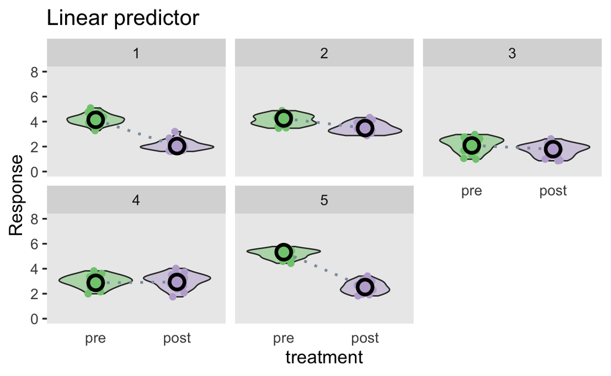

```r
plot_linpred(d1, violin = T)
```

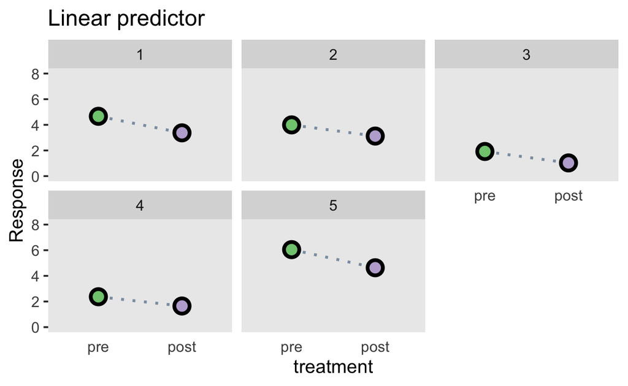

```r
set.seed(52)
d2 <- simulate_treatment(n_subjects = 5,
                        sigma_a = 1.2,
                        sigma_b = 0.2,
                        rho = -0.7)

plot_linpred(d2, violin = F)
```

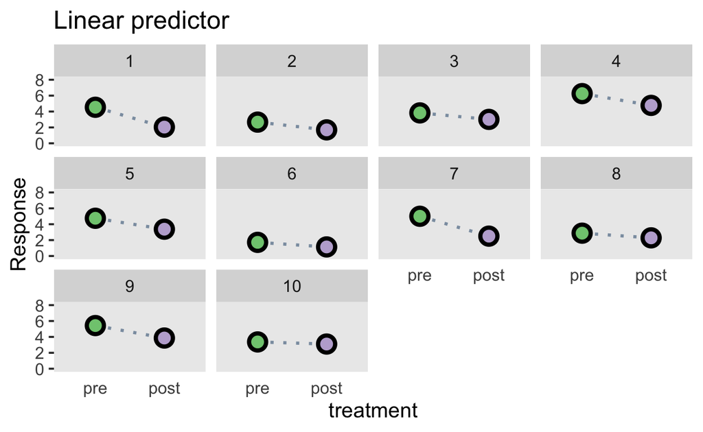

```r
d <- simulate_treatment(n_subjects = 10, n_trials = 50)
plot_linpred(d, violin = F)
```

```r
get_prior(response ~ treatment + (treatment | subject),
          data = d) |>
  as_tibble() |> select(1:4)
```

```
# A tibble: 10 x 4
   prior                    class     coef            group
   <chr>                    <chr>     <chr>           <chr>
 1 ""                       b         ""              ""
 2 ""                       b         "treatmentpost" ""
 3 "lkj(1)"                 cor       ""              ""
 4 ""                       cor       ""              "subject"
 5 "student_t(3, 3.2, 2.5)" Intercept ""              ""
 6 "student_t(3, 0, 2.5)"   sd        ""              ""
 7 ""                       sd        ""              "subject"
 8 ""                       sd        "Intercept"     "subject"
 9 ""                       sd        "treatmentpost" "subject"
10 "student_t(3, 0, 2.5)"   sigma     ""              ""
```

```r
library(rethinking)

n_sim <- 1e5

set.seed(13)
r_1 <-
  rlkjcorr(n_sim, K = 2, eta = 1) %>%
  as_tibble()

set.seed(13)
r_2 <-
  rlkjcorr(n_sim, K = 2, eta = 2) %>%
  as_tibble()

set.seed(13)
r_4 <-
  rlkjcorr(n_sim, K = 2, eta = 4) %>%
  as_tibble()
```

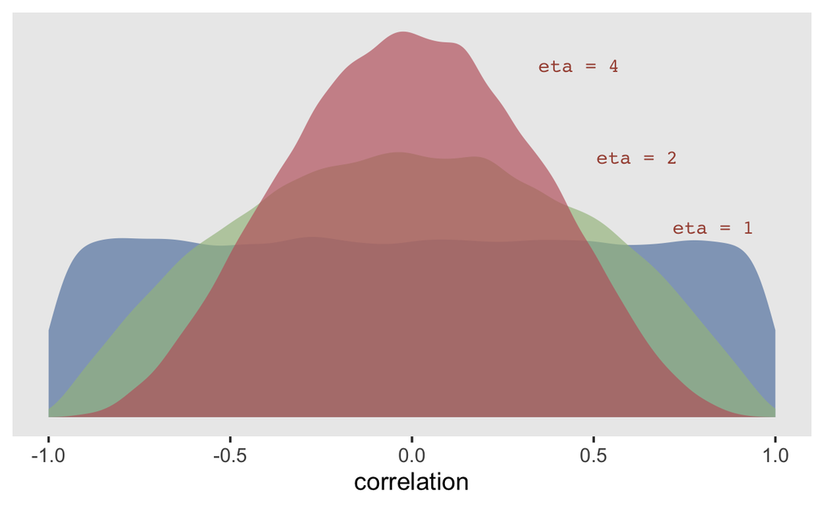

```r
ggplot(data = r_1, aes(x = V2)) +
  geom_density(color = "transparent", fill = "#5e81ac", alpha = 2/3) +
  geom_density(data = r_2,
               color = "transparent", fill = "#a3be8c", alpha = 2/3) +
  geom_density(data = r_4,
               color = "transparent", fill = "#bf616a", alpha = 2/3) +
  geom_text(data = tibble(x = c(.83, .62, .46),
                          y = c(.54, .74, 1),
                          label = c("eta = 1", "eta = 2", "eta = 4")),
            aes(x = x, y = y, label = label),
            color = "#A65141", family = "Courier") +
  scale_y_continuous(NULL, breaks = NULL) +
  xlab("correlation")
```

```r
fit1_prior <- brm(response ~ treatment + (treatment | subject),
            prior = prior(normal(0, 10), class = b),
            data = d,
            sample_prior = "only",
            file = "../../models/02-fit1-prior")

fit1 <- brm(response ~ treatment + (treatment | subject),
            prior = prior(normal(0, 10), class = b),
            data = d,
            file = "../../models/02-fit1")
```

```r
summary(fit1)
```

```
 Family: gaussian
  Links: mu = identity; sigma = identity
Formula: response ~ treatment + (treatment | subject)
   Data: d (Number of observations: 1000)
Samples: 4 chains, each with iter = 2000; warmup = 1000; thin = 1;
         total post-warmup samples = 4000

Group-Level Effects:
~subject (Number of levels: 10)
                             Estimate Est.Error l-95% CI u-95% CI
sd(Intercept)                    0.84      0.23     0.53     1.40
sd(treatmentpost)                0.83      0.24     0.50     1.40
cor(Intercept,treatmentpost)    -0.63      0.21    -0.91    -0.09
                             Rhat Bulk_ESS Tail_ESS
sd(Intercept)                1.00     1399     1558
sd(treatmentpost)            1.00     1268     1742
cor(Intercept,treatmentpost) 1.00     1740     2081

Population-Level Effects:
              Estimate Est.Error l-95% CI u-95% CI Rhat Bulk_ESS
Intercept         3.39      0.28     2.83     3.93 1.00      959
treatmentpost    -0.84      0.26    -1.37    -0.33 1.00     1391
              Tail_ESS
Intercept         1280
treatmentpost     1769

Family Specific Parameters:
      Estimate Est.Error l-95% CI u-95% CI Rhat Bulk_ESS Tail_ESS
sigma     0.49      0.01     0.47     0.52 1.00     3066     2416

Samples were drawn using sampling(NUTS). For each parameter, Bulk_ESS
and Tail_ESS are effective sample size measures, and Rhat is the potential
scale reduction factor on split chains (at convergence, Rhat = 1).
```

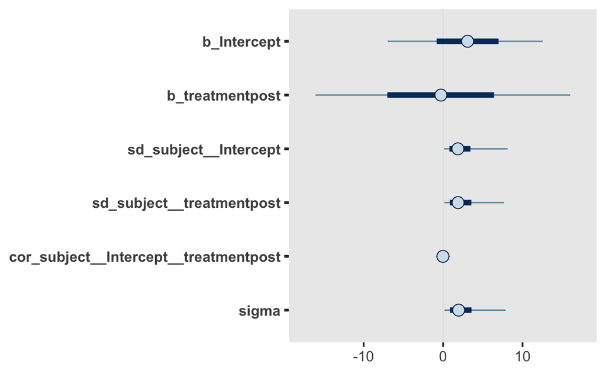

```r
mcmc_plot(fit1_prior)
```

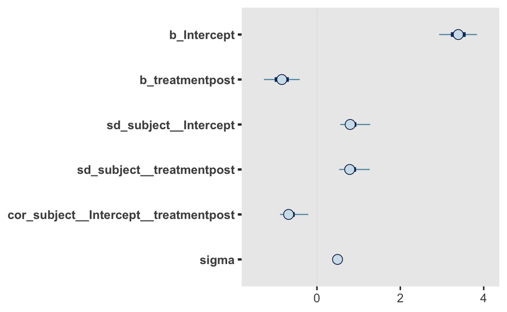

```r
mcmc_plot(fit1)
```

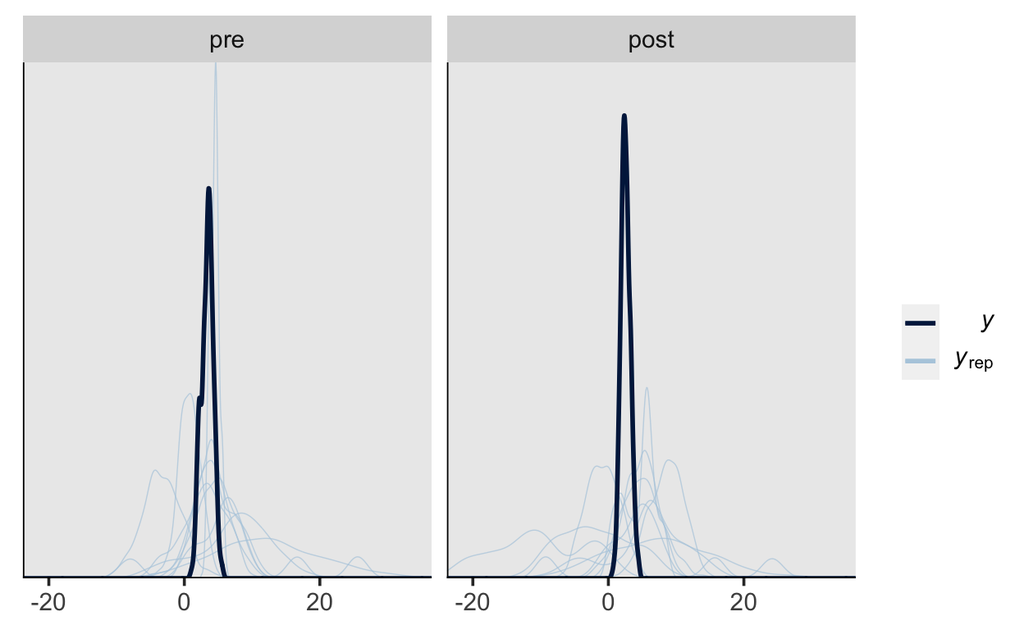

```r
pp_check(fit1_prior, type = "dens_overlay_grouped", group = "treatment")
```

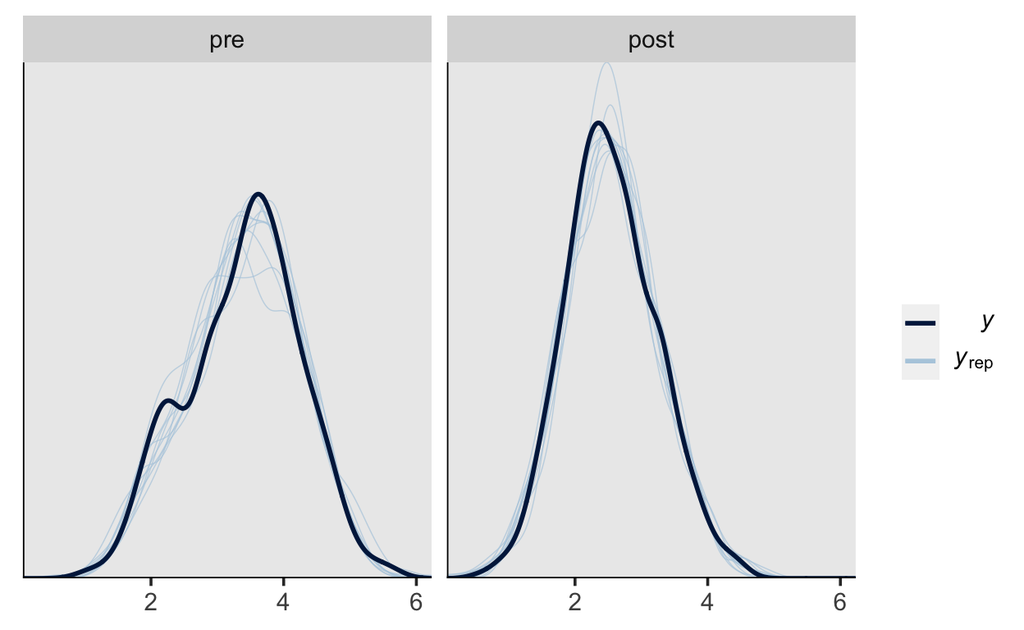

```r
pp_check(fit1, type = "dens_overlay_grouped", group = "treatment")
```

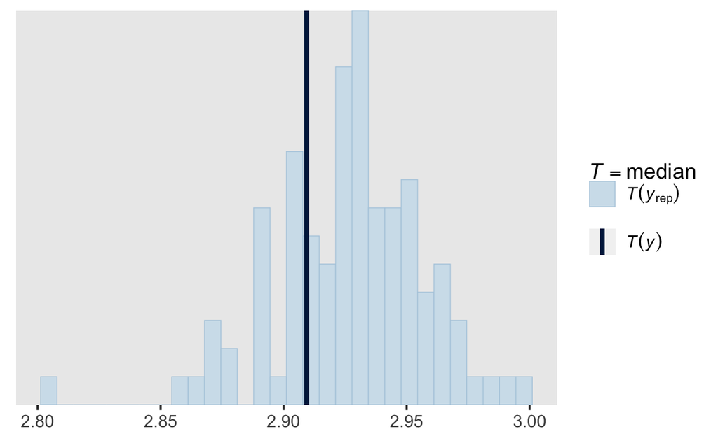

```r
pp_check(fit1, nsamples = 100, type ='stat', stat='median')
```

```r
grid <- d |>
  modelr::data_grid(subject, treatment)

grid
```

```
# A tibble: 20 x 2
   subject treatment
     <int> <fct>
 1       1 pre
 2       1 post
 3       2 pre
 4       2 post
 5       3 pre
 6       3 post
 7       4 pre
 8       4 post
 9       5 pre
10       5 post
11       6 pre
12       6 post
13       7 pre
14       7 post
15       8 pre
16       8 post
17       9 pre
18       9 post
19      10 pre
20      10 post
```

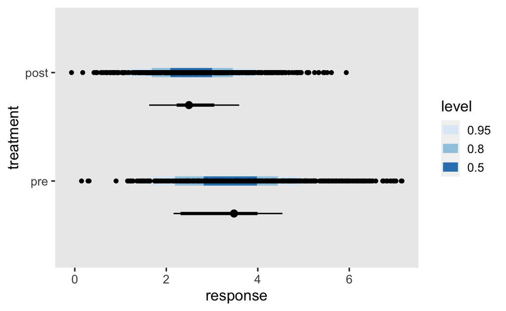

```r
fits <- grid %>%
  add_fitted_draws(fit1)

preds <- grid %>%
  add_predicted_draws(fit1)

d %>%
  ggplot(aes(y = treatment, x = response)) +
  stat_interval(aes(x = .prediction), data = preds) +
  stat_pointinterval(aes(x = .value), data = fits, .width = c(.66, .95),
                     position = position_nudge(y = -0.3)) +
  geom_point() +
  scale_color_brewer()
```

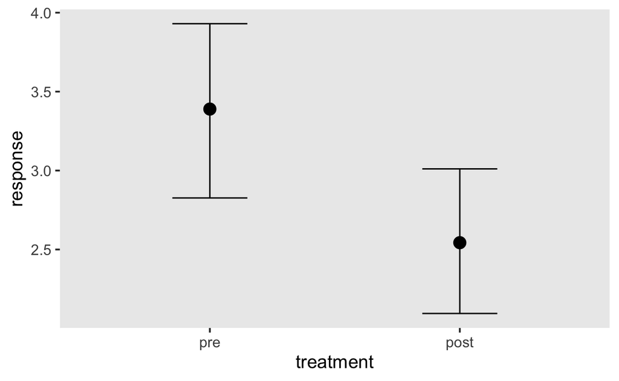

```r
conditional_effects(fit1, re_formula = NA)
```